# Exploratory Data Analysis and Regression

Dylan Maddux

2024-09-16

**Investigate the following data set with one response variable and 20 explanatory variables. We are interested in identifying the variable for which the data shows the strongest relationship with the response. The response variable Y represents a measure of health (e.g., blood pressure, cholesterol level, pain level, etc.), standardized to have a mean of 0 and a standard deviation of 1. Each of the explanatory variables represents a potential comorbidity factor (e.g., age, blood sugar, weight, etc.) that could potentially affect the response variable. The explanatory variables have likewise been standardized to have mean 0 and standard deviation 1.**

**Question 1** Load both data sets.

```r
library(dplyr)
library(ggplot2)
group_number <- 5

long_data <- read.csv(paste("https://grinnell-statistics.github.io/sta-310-s24/data/reproducible/long_data",group_number,".csv", sep = "")) %>% select(-X)

wide_data <- read.csv(paste("https://grinnell-statistics.github.io/sta-310-s24/data/reproducible/wide_data",group_number,".csv", sep = "")) %>% select(-X)
```

**Question 2** Using the long data, create scatterplots showing the relationship between the response and each explanatory variable. Add a regression line to each plot to help visualize the relationship.

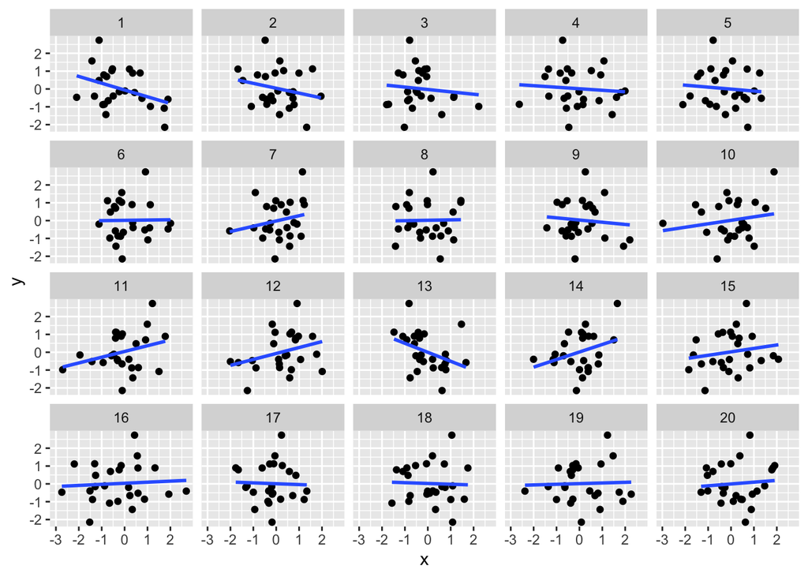

```r
ggplot(data = long_data, aes(x = x, y = y)) +
       geom_point() +
      geom_smooth(method = "lm", se = F) +
       facet_wrap(~variable)
```

**Question 3** Find the correlation coefficient for the response and each explanatory variable.

```r
long_data %>% group_by(variable) %>% summarize(mycors = cor(x, y))
```

```
## # A tibble: 20 × 2
##    variable  mycors
##       <int>   <dbl>
##  1        1 -0.372
##  2        2 -0.227
##  3        3 -0.110
##  4        4 -0.0891
##  5        5 -0.0948
##  6        6  0.0124
##  7        7  0.212
##  8        8  0.0179
##  9        9 -0.0975
## 10       10  0.183
## 11       11  0.300
## 12       12  0.310
## 13       13 -0.371
## 14       14  0.324
## 15       15  0.181
## 16       16  0.0702
## 17       17 -0.0356
## 18       18 -0.0364
## 19       19  0.0367
## 20       20  0.0885
```

**Question 4** Based on the scatterplots and correlation coefficients, identify the variable that your group believes is most strongly associated with the response variable.

Based on the scatterplots and correlation coefficients, we believe that variable 1 is most strongly associated with the response variable since the correlation coefficient is the highest and the regression line seems strongest.

**Question 5** Use the wide data to create a linear model for the response variable as a function of the explanatory variable that you chose in #4. Display the summary table for the model fit, including the equation for the regression line, the p-value for the slope, and the value of R^2.

```r
model <- lm(y~x1, wide_data)
summary(model)
```

```
##
## Call:
## lm(formula = y ~ x1, data = wide_data)
##
## Residuals:
##      Min       1Q   Median       3Q      Max
## -1.68926 -0.84985 -0.04761  0.87415  2.36671
##
## Coefficients:
##             Estimate Std. Error t value Pr(>|t|)
## (Intercept) -0.05753    0.21003  -0.274   0.7866
## x1          -0.38024    0.19792  -1.921   0.0672 .
## ---
## Signif. codes:  0 '***' 0.001 '**' 0.01 '*' 0.05 '.' 0.1 ' ' 1
##
## Residual standard error: 1.032 on 23 degrees of freedom
## Multiple R-squared:  0.1383, Adjusted R-squared:  0.1008
## F-statistic: 3.691 on 1 and 23 DF,  p-value: 0.06719
```

**Question 6** Use diagnostic plots to assess whether the conditions for using the linear regression model have been met.

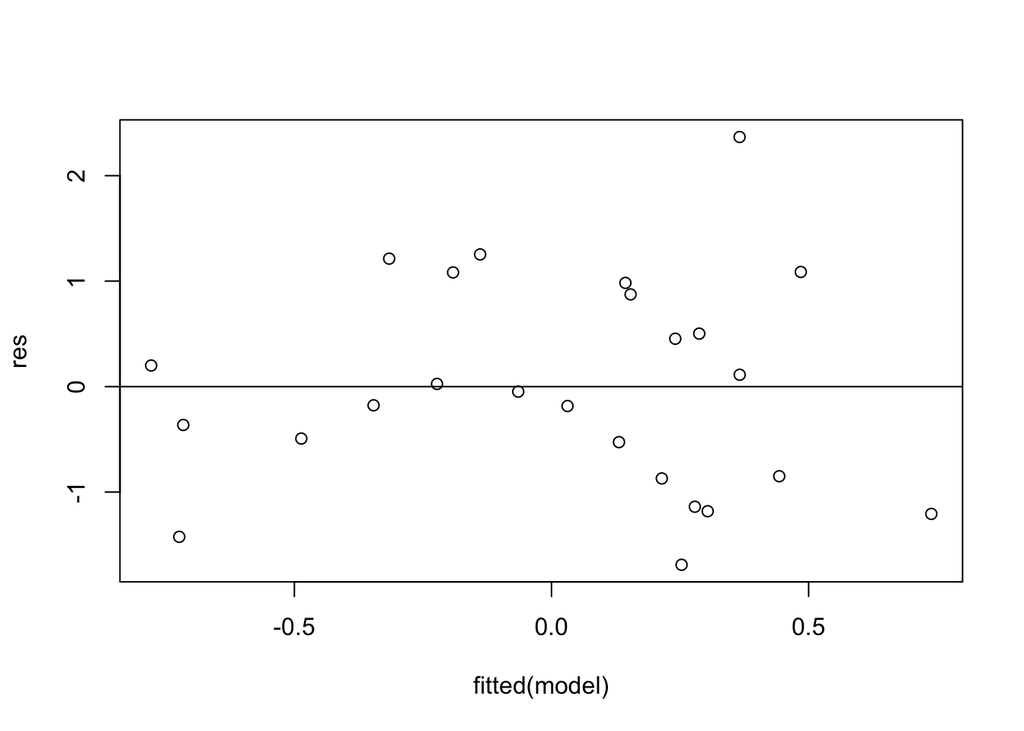

```r
res <- resid(model)
plot(fitted(model), res)
abline(0,0)
```

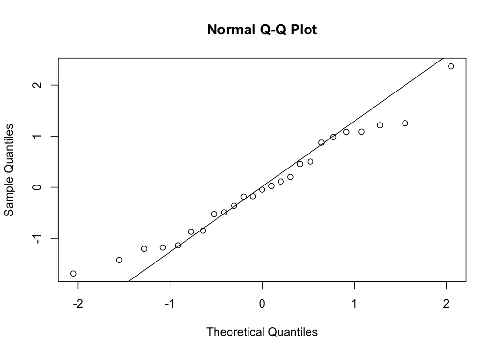

```r
qqnorm(res)
qqline(res)
```

The conditions for using the linear regression model are not fully met because there is evident heteroscedasticity in the fitted residual plot, while the Q-Q plot displays kurtosis.

**Question 7** Prepare a statement about which variable shows the strongest association with the response, along with evidence for your claim.

Variable 1 shows the strongest association with the response because its correlation coefficient with the outcome variable ‘y’ is the highest out of all the variables, while the regression plot and model display a decent level of association.